# Homework #5: Probability and Classification

# Problem 3: ROC Curves

## a. ROC curve: training data

Produce one plot that has the ROC curves, using the *training data*, for all three models (linear, logistic, and random forest). Use color and/or linetype to distinguish between models and include a legend.  
Also report the AUC (area under the ROC curve) for each model. Again, use the *training data*.

- Note: you should be weary of being asked to evaluation predictive performance from the same data used to estimate the tuning and model parameters. The next problem will walk you through a more proper way of evaluating predictive performance with resampling.

**Solution**

```r
# Load necessary libraries
library(yardstick)  # For evaluation functions (roc_curve, roc_auc)
library(ggplot2)    # For plotting
library(dplyr)      # For data manipulation
library(tidyr)      # For pivot_longer

# Prepare a data frame with the predictions from each model
test_perf <- tibble(
  truth = factor(cld_train_s$y, levels = c(1, 0)),  # Ensure binary factor (0 and 1)
  linear = as.numeric(yhat_enet_linear),       # Continuous predictions from linear model
  logistic = as.numeric(yhat_probs_logistic),  # Probabilities from logistic regression
  random_forest = as.numeric(y_hat_rforest)    # Predictions from random forest
)

# Compute ROC curves for each model
roc_linear <- roc_curve(test_perf, truth, linear)
roc_logistic <- roc_curve(test_perf, truth, logistic)
roc_rf <- roc_curve(test_perf, truth, random_forest)

# Add a 'model' label to each ROC curve
roc_linear <- roc_linear %>% mutate(model = "Linear")
roc_logistic <- roc_logistic %>% mutate(model = "Logistic")
roc_rf <- roc_rf %>% mutate(model = "Random Forest")

# Combine the ROC data from all models
roc_combined <- bind_rows(roc_linear, roc_logistic, roc_rf)

# Compute the AUC for each model
auc_linear <- roc_auc(test_perf, truth, linear)
auc_logistic <- roc_auc(test_perf, truth, logistic)
auc_rf <- roc_auc(test_perf, truth, random_forest)

# Print the AUC values
print(paste("AUC for Linear Model:", auc_linear$.estimate))
```

```
[1] "AUC for Linear Model: 0.920925903033081"
```

```r
print(paste("AUC for Logistic Model:", auc_logistic$.estimate))
```

```
[1] "AUC for Logistic Model: 0.935457198420543"
```

```r
print(paste("AUC for Random Forest Model:", auc_rf$.estimate))
```

```
[1] "AUC for Random Forest Model: 0.999994451586335"
```

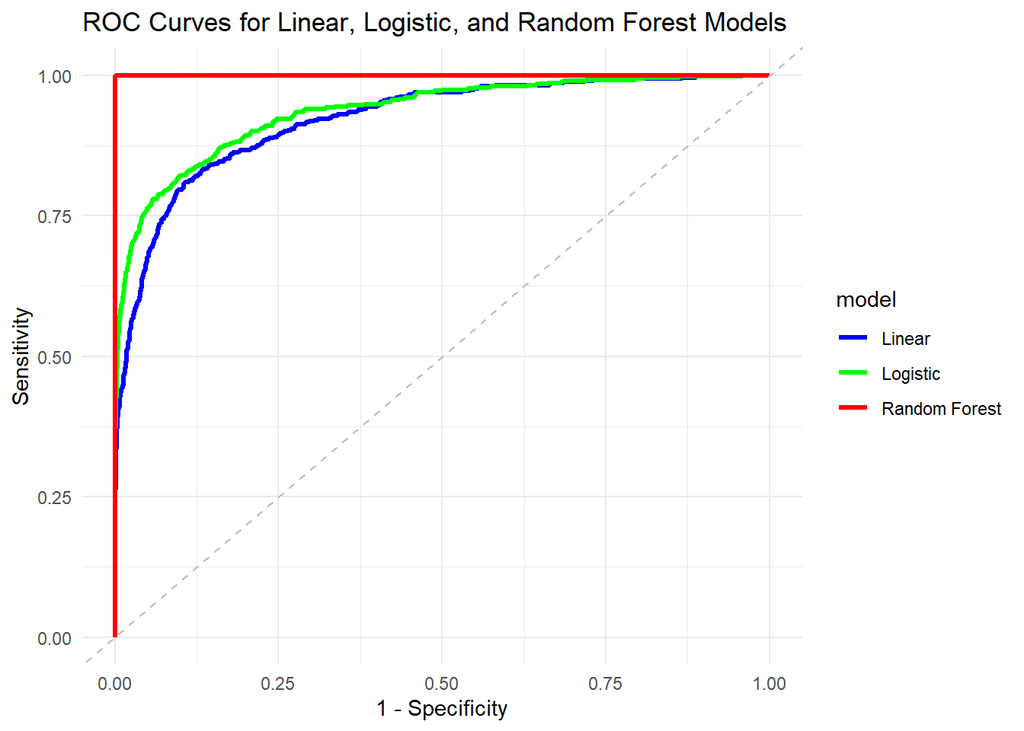

```r
# Plot the combined ROC curves using ggplot
ggplot(roc_combined, aes(x = 1 - specificity, y = sensitivity, color = model)) +
  geom_path(size = 1.2) +
  geom_abline(lty = 2, color = "gray") +  # Reference line for random guessing
  labs(title = "ROC Curves for Linear, Logistic, and Random Forest Models",
       x = "1 - Specificity",
       y = "Sensitivity") +
  theme_minimal() +
  scale_color_manual(values = c("Linear" = "blue", "Logistic" = "green", "Random Forest" = "red"))
```

## b. ROC curve: resampling estimate

Recreate the ROC curve from the penalized logistic regression (logreg) and random forest (rf) models using repeated hold-out data. The following steps will guide you:

- For logreg, use $\alpha=.75$. For rf use *mtry = 2*, *num.trees = 1000*, and fix any other tuning parameters at your choice.
- Run the following steps 25 times:
  1. Hold out 500 observations.
  2. Use the remaining observations to estimate $\lambda$ using 10-fold CV for the logreg model. Don’t tune any rf parameters.
  3. Predict the probability of linkage for the 500 hold-out observations.
  4. Store the predictions and hold-out labels.
  5. Calculate the AUC.
- Report the mean AUC and standard error for both models. Compare to the results from part a.
- Produce two plots showing the 25 ROC curves for each model.
- Note: by estimating $\lambda$ each iteration, we are incorporating the uncertainty present in estimating that tuning parameter.

**Solution**

```r
# Load necessary libraries
library(glmnet)
library(ranger)
library(yardstick)
library(ggplot2)
library(dplyr)
library(purrr)

# Set parameters
set.seed(123)           # For reproducibility
n_iterations <- 25      # Number of iterations


# Initialize vectors to store AUCs for both models
auc_logreg <- vector("numeric", n_iterations)
auc_rf <- vector("numeric", n_iterations)

# Initialize lists to store ROC curve data
roc_logreg_list <- list()
roc_rf_list <- list()

# Repeat the process 25 times
for (i in 1:25) {

  # Step i: Split data into training and hold-out sets
  holdout_idx <- sample(1:nrow(cld_train_s), 500) # holdout size=500
  holdout_data <- cld_train_s[holdout_idx, ]
  training_data <- cld_train_s[-holdout_idx, ]
 #------------------------
  #Logistic

  # Step ii: Logistic regression (penalized logreg with alpha = 0.75)
  X_train <- as.matrix(training_data[, -which(names(training_data) == "y")])
  y_train <- training_data$y

  # Perform 10-fold CV to estimate lambda for logistic regression
  cv_logreg <- cv.glmnet(X_train, y_train, alpha = 0.75, family = "binomial", nfolds = 10)
  best_lambda <- cv_logreg$lambda.min  # Best lambda from cross-validation

  # Step iii: Predict the holdout observations using penalized logreg
  X_holdout <- as.matrix(holdout_data[, -which(names(holdout_data) == "y")])
  y_holdout <- holdout_data$y
  yhat_logreg <- predict(cv_logreg, newx = X_holdout, s = best_lambda, type = "response")[,1] # adding this one makes it a vector
#---------------------------------------------

  #Random Forest
  # Step ii: Random forest (fixed parameters)
  rf_model <- ranger(
    formula = y ~ .,
    data = training_data,
    num.trees = 1000,
    mtry = 2
    # Predict class probabilities
  )

  # Step iii: Predict the holdout observations using random forest
  yhat_rf <- predict(rf_model, data = holdout_data)$predictions

  #-----------------------
  #AUC

  # Step v: Calculate AUC for both models
  auc_logreg[i] <- roc_auc_vec(as.factor(y_holdout), yhat_logreg) # make a vector as well
  auc_rf[i] <- roc_auc_vec(as.factor(y_holdout), yhat_rf) # make a vector

  # make a dataframe/ tible as above and specify which columns from it to pass in below
  Preds_tibble<-tibble(
  truth = factor(y_holdout, levels = c(1,0)),  # Ensure this is binary (0 and 1)
  logreg_preds = as.numeric(yhat_logreg),
  rf_preds=as.numeric(yhat_rf))

  # Step vi: Store ROC curve data for plotting, needs df, then columsn specified
  roc_logreg_list[[i]] <- roc_curve(Preds_tibble, truth, logreg_preds)
  roc_rf_list[[i]] <- roc_curve(Preds_tibble, truth, rf_preds)
}

# Calculate mean and standard error for AUCs
mean_auc_logreg <- mean(auc_logreg)
se_auc_logreg <- sd(auc_logreg) / sqrt(n_iterations)

mean_auc_rf <- mean(auc_rf)
se_auc_rf <- sd(auc_rf) / sqrt(n_iterations)

# Print the results
print(paste("Mean AUC for LogReg:", mean_auc_logreg))
```

```
[1] "Mean AUC for LogReg: 0.0721779744662013"
```

```r
print(paste("Standard Error for LogReg:", se_auc_logreg))
```

```
[1] "Standard Error for LogReg: 0.0103801262260148"
```

```r
print(paste("Mean AUC for RF:", mean_auc_rf))
```

```
[1] "Mean AUC for RF: 0.0814676548248904"
```

```r
print(paste("Standard Error for RF:", se_auc_rf))
```

```
[1] "Standard Error for RF: 0.0128023550400151"
```

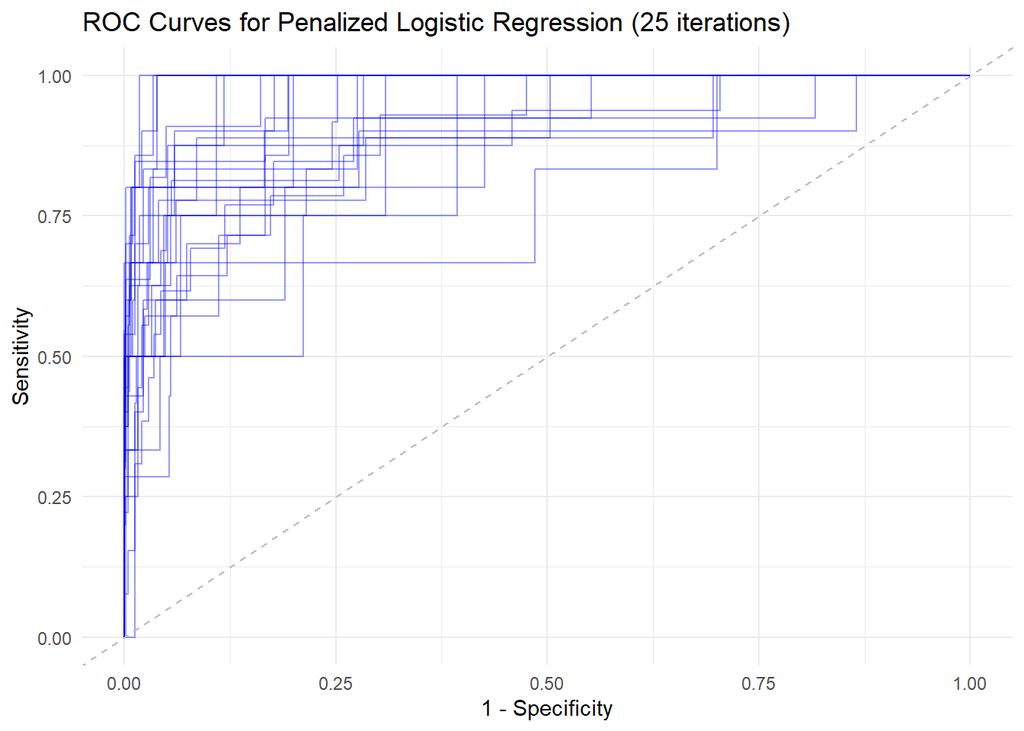

```r
# Step 4: Combine all ROC curve data into one dataframe
roc_logreg_data <- bind_rows(roc_logreg_list, .id = "iteration") %>% mutate(model = "LogReg")
roc_rf_data <- bind_rows(roc_rf_list, .id = "iteration") %>% mutate(model = "RandomForest")

# Step 5: Plot ROC curves for both models

# Plot ROC curves for Logistic Regression
ggplot(roc_logreg_data, aes(x = 1 - specificity, y = sensitivity, group = iteration)) +
  geom_path(alpha = 0.4, color = "blue") +
  geom_abline(lty = 2, color = "gray") +
  labs(title = "ROC Curves for Penalized Logistic Regression (25 iterations)",
       x = "1 - Specificity",
       y = "Sensitivity") +
  theme_minimal()
```

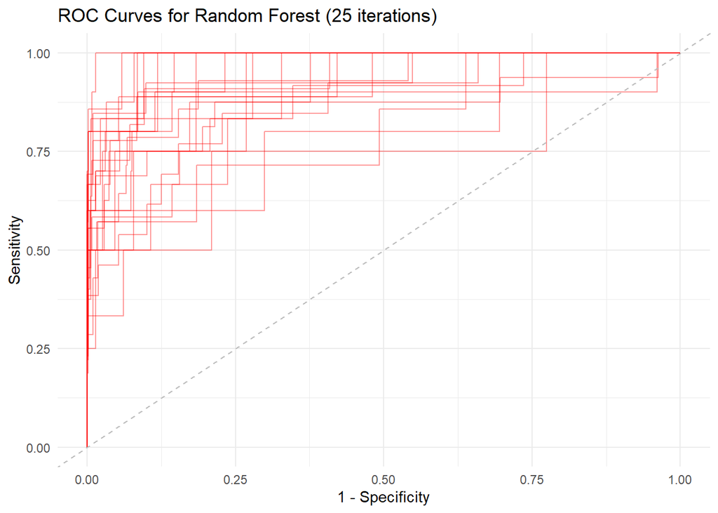

```r
# Plot ROC curves for Random Forest
ggplot(roc_rf_data, aes(x = 1 - specificity, y = sensitivity, group = iteration)) +
  geom_path(alpha = 0.4, color = "red") +
  geom_abline(lty = 2, color = "gray") +
  labs(title = "ROC Curves for Random Forest (25 iterations)",
       x = "1 - Specificity",
       y = "Sensitivity") +
  theme_minimal()
```

# Problem 4: Contest

## a. Contest Part 1: Predict the estimated *probability* of linkage.

Predict the estimated *probability* of linkage for the test data (using any model).

- Submit a .csv file (ensure comma separated format) named `lastname_firstname_1.csv` that includes the column named **p** that is your estimated posterior probability. We will use automated evaluation, so the format must be exact.
- You are free to any model (even ones we haven’t yet covered in the course).
- You are free to use any data transformation or feature engineering.
- You will receive credit for a proper submission; the top five scores will receive 2 bonus points.
- Your probabilities will be evaluated with respect to the mean negative Bernoulli log-likelihood (known as the average *log-loss* metric):
  $$L = - \frac{1}{M} \sum_{i=1}^m [y_i \log \, \hat{p}_i + (1 - y_i) \log \, (1 - \hat{p}_i)]$$
  where $M$ is the number of test observations, $\hat{p}_i$ is the prediction for the $i$th test observation, and $y_i \in \{0,1\}$ are the true test set labels.

**Solution**

```r
# Fit the random forest model using ranger on the training data
rf_m <- ranger(y ~ .-y, data = cld_train_s,
                     num.trees = 1000, mtry = 5,
                     importance = 'impurity',
                    replace=T,
                      probability = T)



# Make predictions on the training set also per the instructions-not typical, usually do it on the test set
preds_rforest <- predict(rf_m, cld_test_s)$predictions
# this has two columsn: prob of no linkage and prob of linkage

# extract the probability of linkage
prob_link_col <- preds_rforest[, 1]
#prob_link_col

file.remove("McLaughlin_Ainsley_1.csv")
```

```
[1] TRUE
```

```r
# send to a csv:
library(readr)

# Convert probs to a data frame and explicitly name the column as 'p'
probs_df <- data.frame(p = as.vector(prob_link_col))

# Write to CSV again
write_csv(probs_df, "McLaughlin_Ainsley_1.csv")
```

Click below to get the predictions:

Download predictions cvs

## b. Contest Part 2: Predict the *linkage label*.

Predict the linkages for the test data (using any model).

- Submit a .csv file (ensure comma separated format) named `lastname_firstname_2.csv` that includes the column named **linkage** that takes the value of 1 for linked pairs and 0 for unlinked pairs. We will use automated evaluation, so the format must be exact.
- You are free to any model (even ones we haven’t yet covered in the course).
- You are free to use any data transformation or feature engineering.
- Your labels will be evaluated based on total cost, where cost is equal to `1*FP + 8*FN`. This implies that False Negatives (FN) are 8 times as costly as False Positives (FP).
- You will receive credit for a proper submission; the top five scores will receive 2 bonus points. Note: you only will get bonus credit for one of the two contests.

**Solution**

```r
# Fit the random forest model using ranger on the training data
rf_m2 <- ranger(y ~ .-y, data = cld_train_s,
                     num.trees = 1000, mtry = 5,
                     importance = 'impurity',
                replace=T,
                      classification=T,
                      probability = F)



# Make predictions on the training set also per the instructions-not typical, usually do it on the test set
preds_rforest2 <- predict(rf_m2, cld_test_s)$predictions
file.remove("McLaughlin_Ainsley_2.csv")
```

```
[1] TRUE
```

```r
# Convert probs to a data frame and explicitly name the column as 'p'
probs_df2 <- data.frame(linkages = as.vector(preds_rforest2))

# Write to CSV again
write_csv(probs_df2, "McLaughlin_Ainsley_2.csv")
```